# Exploratory Data Analysis in R - Diagnosing Like a Data Doctor

Greg Chism

2022/Sept/05

## Purpose of workshop

**Exploring a novel data set and produce publication quality tables and reports**

## Objectives

1. Load and explore a data set with publication quality tables
2. Diagnose outliers and missing values in a data set
3. Prepare an HTML summary report showcasing properties of a data set

## Required Setup

We first need to prepare our environment with the necessary packages

```r
# Sets the number of significant figures to two - e.g., 0.01
options(digits = 2)

# Required package for quick package downloading and loading
if (!require(pacman))
  install.packages("pacman")

# Downloads and load required packages
pacman::p_load(dlookr, # Exploratory data analysis
               formattable, # HTML tables from R outputs
               here, # Standardizes paths to data
               kableExtra, # Alternative to formattable
               knitr, # Needed to write HTML reports
               missRanger, # To generate NAs
               tidyverse) # Powerful data wrangling package suite
```

## Load and Examine a Data Set

- Load data and view
- Examine columns and data types
- Define box plots
- Describe meta data

We will be using open source data from UArizona researchers for Test, Trace, Treat (T3) efforts offers two clinical diagnostic tests (Antigen, RT-PCR) to determine whether an individual is currently infected with the COVID-19 virus. (Merchant et al. 2022)

```r
# Let's load a data set from the COVID-19 daily testing data set
dataset <- read.csv(here("EDA_In_R_Book", "data", "daily_summary.csv"))

# What does the data look like?
dataset |>
  head() |>
  formattable()
```

| result_date | affil_category | test_type | test_result | test_count | test_source |
| --- | --- | --- | --- | --- | --- |
| 2020-08-04 | Employee | Antigen | Negative | 5 | Campus Health |
| 2020-08-04 | Employee | Antigen | Positive | 0 | Campus Health |
| 2020-08-04 | Employee | Antigen | Negative | 1 | Test All Test Smart |
| 2020-08-04 | Employee | Antigen | Positive | 0 | Test All Test Smart |
| 2020-08-04 | Off-Campus Student | Antigen | Negative | 9 | Campus Health |
| 2020-08-04 | Off-Campus Student | Antigen | Positive | 1 | Campus Health |

## Diagnose your Data

```r
# What are the properties of the data
dataset |>
  diagnose() |>
  formattable()
```

| variables | types | missing_count | missing_percent | unique_count | unique_rate |
| --- | --- | --- | --- | --- | --- |
| result_date | character | 0 | 0 | 541 | 0.05893 |
| affil_category | character | 0 | 0 | 4 | 0.00044 |
| test_type | character | 0 | 0 | 3 | 0.00033 |
| test_result | character | 0 | 0 | 3 | 0.00033 |
| test_count | integer | 0 | 0 | 591 | 0.06438 |
| test_source | character | 0 | 0 | 2 | 0.00022 |

- `variables`: name of each variable
- `types`: data type of each variable
- `missing_count`: number of missing values
- `missing_percent`: percentage of missing values
- `unique_count`: number of unique values
- `unique_rate`: rate of unique value - unique_count / number of observations

## Summary Statistics of your Data

### Numerical Variables

```r
# Summary statistics of our numerical columns
dataset |>
  diagnose_numeric() |>
  formattable()
```

| variables | min | Q1 | mean | median | Q3 | max | zero | minus | outlier |
| --- | --- | --- | --- | --- | --- | --- | --- | --- | --- |
| test_count | 0 | 0 | 47 | 2 | 16 | 1472 | 2777 | 0 | 1721 |

- `min`: minimum value
- `Q1`: 1/4 quartile, 25th percentile
- `mean`: arithmetic mean (average value)
- `median`: median, 50th percentile
- `Q3`: 3/4 quartile, 75th percentile
- `max`: maximum value
- `zero`: number of observations with the value 0
- `minus`: number of observations with negative numbers
- `outlier`: number of outliers

### Outliers

Values outside of $1.5 * IQR$

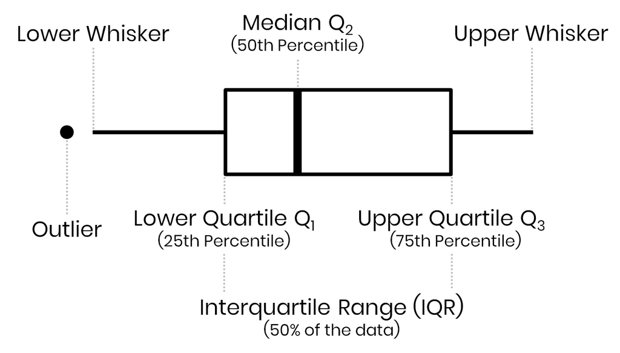

Image Credit: [CÉDRIC SCHERER](https://www.cedricscherer.com/2019/05/17/the-evolution-of-a-ggplot-ep.-1/)

- Create a table with columns containing outliers
- Plot outliers in a box plot and histogram

```r
# Table showing outliers
diagnose_outlier(dataset) |>
  filter(outliers_ratio > 0) |>
  formattable()
```

| variables | outliers_cnt | outliers_ratio | outliers_mean | with_mean | without_mean |
| --- | --- | --- | --- | --- | --- |
| test_count | 1721 | 19 | 231 | 47 | 4.3 |

- `outliers_cnt`: number of outliers
- `outliers_ratio`: ratio of outliers over all values
- `outliers_mean`: arithmetic mean (average value) of outlier values
- `with_mean`: arithmetic mean of all values **including** outliers
- `without_mean`: arithmetic mean of all values **excluding** outliers

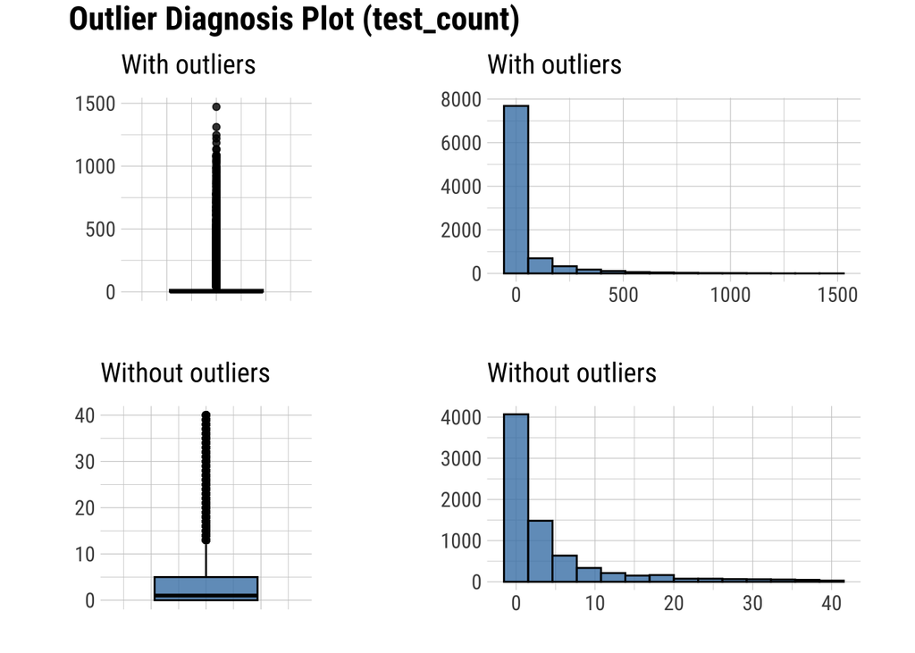

```r
# Selecting desired columns
dataset |>
    plot_outlier()
```

### Missing Values (NAs)

- Table showing the extent of NAs in columns containing them
- Plot showing the frequency of missing values

```r
# Create the NA table
dataset |>
  generateNA(p = 0.3) |>
  plot_na_pareto(only_na = TRUE, plot = FALSE) |>
  formattable() # Publishable table
```

| variable | frequencies | ratio | grade | cumulative |
| --- | --- | --- | --- | --- |
| affil_category | 2754 | 0.3 | Bad | 17 |
| result_date | 2754 | 0.3 | Bad | 33 |
| test_count | 2754 | 0.3 | Bad | 50 |
| test_result | 2754 | 0.3 | Bad | 67 |
| test_source | 2754 | 0.3 | Bad | 83 |
| test_type | 2754 | 0.3 | Bad | 100 |

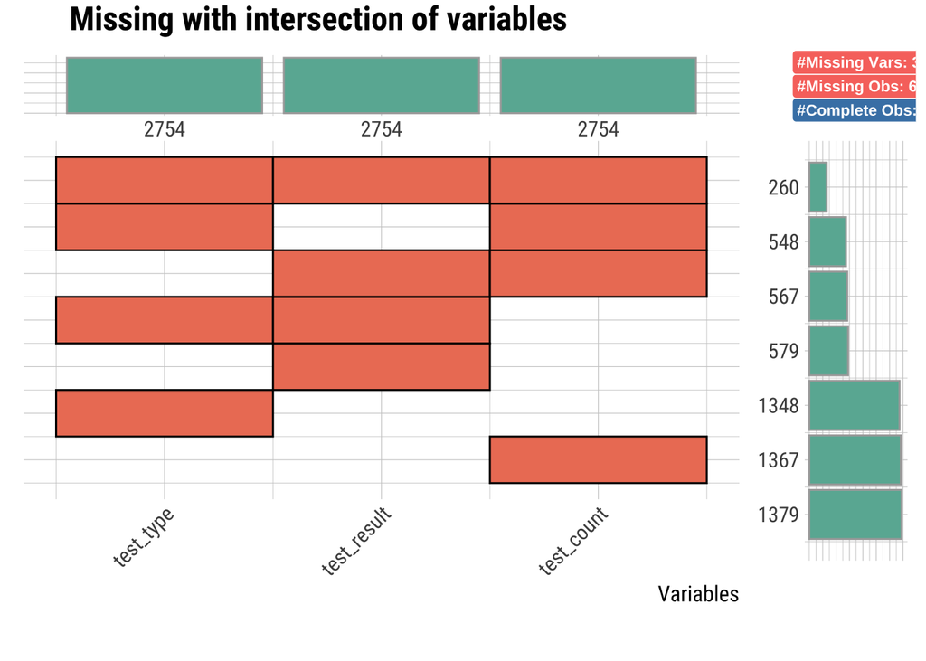

```r
# Plot the intersect of the columns with the most missing values
# This means that some combinations of columns have missing values in the same row
dataset |>
  generateNA(p = 0.3) |>
  select(test_type, test_result, test_count) |>
  plot_na_intersect(only_na = TRUE)
```

### Categorical Variables

```r
# Diagnose our categorical columns
dataset |>
  diagnose_category() |>
  formattable()
```

| variables | levels | N | freq | ratio | rank |
| --- | --- | --- | --- | --- | --- |
| result_date | 2020-09-17 | 9180 | 26 | 0.283 | 1 |
| result_date | 2020-09-23 | 9180 | 26 | 0.283 | 1 |
| result_date | 2020-10-01 | 9180 | 26 | 0.283 | 1 |
| result_date | 2020-10-08 | 9180 | 26 | 0.283 | 1 |
| result_date | 2020-09-01 | 9180 | 25 | 0.272 | 5 |
| result_date | 2020-09-16 | 9180 | 25 | 0.272 | 5 |
| result_date | 2020-09-24 | 9180 | 25 | 0.272 | 5 |
| result_date | 2020-12-09 | 9180 | 25 | 0.272 | 5 |
| result_date | 2020-12-15 | 9180 | 25 | 0.272 | 5 |
| result_date | 2020-09-04 | 9180 | 24 | 0.261 | 10 |
| affil_category | Off-Campus Student | 9180 | 3368 | 36.688 | 1 |
| affil_category | Employee | 9180 | 2987 | 32.538 | 2 |
| affil_category | On-Campus Student | 9180 | 2823 | 30.752 | 3 |
| affil_category | Other | 9180 | 2 | 0.022 | 4 |
| test_type | Antigen | 9180 | 4624 | 50.370 | 1 |
| test_type | PCR | 9180 | 4554 | 49.608 | 2 |
| test_type | Antibody | 9180 | 2 | 0.022 | 3 |
| test_result | Negative | 9180 | 4575 | 49.837 | 1 |
| test_result | Positive | 9180 | 4575 | 49.837 | 1 |
| test_result | Inconclusive | 9180 | 30 | 0.327 | 3 |
| test_source | Test All Test Smart | 9180 | 5078 | 55.316 | 1 |
| test_source | Campus Health | 9180 | 4102 | 44.684 | 2 |

- `variables`: category names
- `levels`: group names within categories
- `N`: number of observation
- `freq`: number of observation at group level / number of observation at category level
- `ratio`: percentage of observation at group level / number of observation at category level
- `rank`: rank of the occupancy ratio of levels (order in which the groups are in the category)

## Produce an HTML Summary of a Data Set

```r
# Remove the '#' below to reproduce an HTML from an R script.
diagnose_web_report(dataset)
```

Merchant, Nirav C, Jim Davis, George H Franks, Chun Ly, Fernando Rios, Todd Wickizer, Gary D Windham, and Michelle Yung. 2022. “University of Arizona Test-Trace-Treat COVID-19 Testing Results.” University of Arizona Research Data Repository. https://doi.org/10.25422/AZU.DATA.14869740.V3.